# Extensions to the Grammar of Graphics

### position_nudge_to()

Function `position_nudge_to()` nudges to a given position instead of using the same shift for each observation. Can be used to align labels for points that are not themselves aligned. By left-justifying the label text we ensure the alignment of labels differing in width.

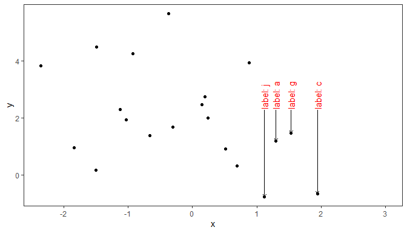

```r
ggplot(df, aes(x, y, label = ifelse(x < 1, "", l) )) +
  geom_point() +
  geom_text_s(position = position_nudge_to(y = 2.3),
              colour = "red",
              arrow = arrow(length = unit(0.015, "npc")),
              angle = 90) +
  expand_limits(x = 3)
```

This function also supports distributing the positions in the available space, with action `“spread”.

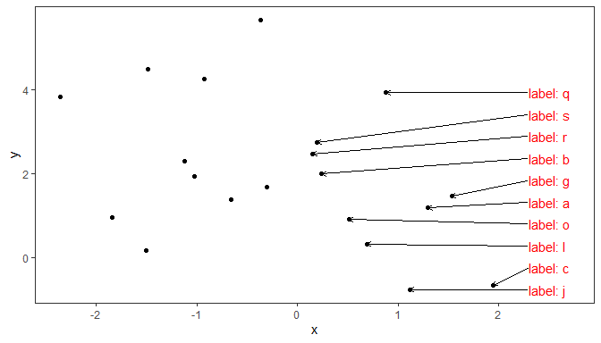

```r
ggplot(df, aes(x, y, label = l)) +
  geom_point() +
  geom_text_s(data = function(x) {x[x$x > 0, ]},
              position = position_nudge_to(x = 2.3, y.action = "spread"),
              colour = "red",
              arrow = arrow(length = unit(0.015, "npc")),
              vjust = 0.5) +
  expand_limits(x = 2.7)
```

The space used can be expanded.

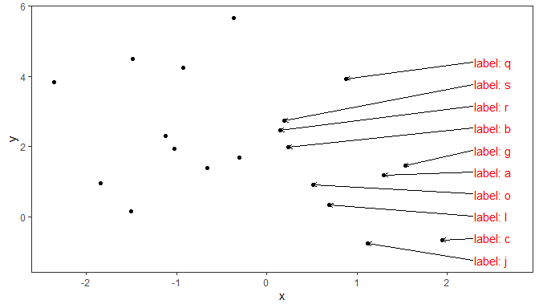

```r
ggplot(df, aes(x, y, label = l)) +
  geom_point() +
  geom_text_s(data = function(x) {x[x$x > 0, ]},
              position = position_nudge_to(x = 2.3,
                                           y.action = "spread",
                                           y.expansion = 0.1),
              colour = "red",
              arrow = arrow(length = unit(0.015, "npc")),
              vjust = 0.5) +
  expand_limits(x = 2.7)
```

The range can be also set manually.

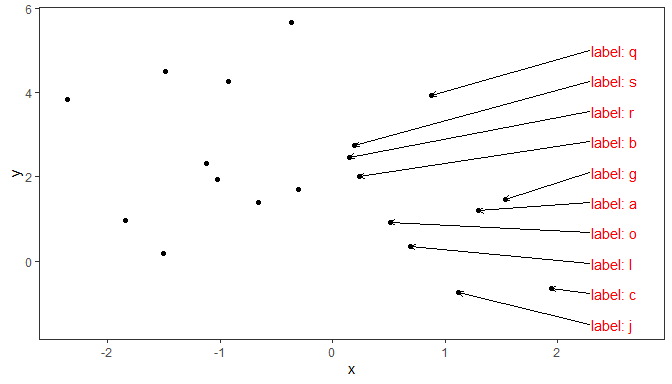

```r
ggplot(df, aes(x, y, label = l)) +
  geom_point() +
  geom_text_s(data = function(x) {x[x$x > 0, ]},
              position = position_nudge_to(x = 2.3,
                                           y = c(-1.5, 5),
                                           y.action = "spread"),
              colour = "red",
              arrow = arrow(length = unit(0.015, "npc")),
              vjust = 0.5) +
  expand_limits(x = 2.7)
```

### position_nudge_center()

Function `position_nudge_center()` can nudge radially away from a focal point if both `x` and `y` are passed as arguments, or towards opposite sides of a boundary vertical or horizontal *virtual* line if only one of `x` or `y` is passed an argument. By default, the “center” is the centroid computed using `mean()`, but other functions or numeric values can be passed to override it. When data are sparse, such nudging may be effective in avoiding label overlaps, and achieving a visually pleasing positioning.

In all cases nudging shifts the coordinates giving an *x* and/or *y* position and also expands the limits of the corresponding scales to include the nudged coordinate values.

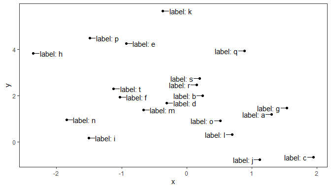

```r
ggplot(df, aes(x, y, label = l)) +
  geom_point() +
  geom_text_s(position =
                    position_nudge_center(x = -0.1, center_x = 0))
```

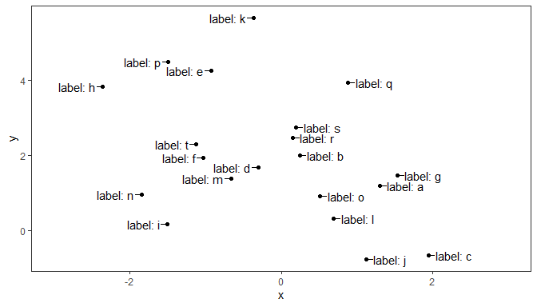

```r
ggplot(df, aes(x, y, label = l)) +
  geom_point() +
  geom_text_s(position = position_nudge_center(x = 0.1, direction = "split")) +
  expand_limits(x = c(-3, 3))
```

We set a different split point as a constant value.

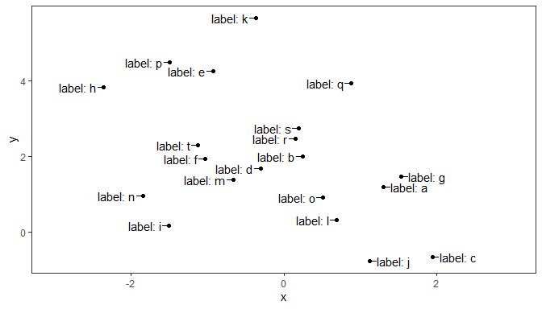

```r
ggplot(df, aes(x, y, label = l)) +
  geom_point() +
  geom_text_s(position =
                position_nudge_center(x = 0.1,
                                      center_x = 1,
                                      direction = "split")) +
  expand_limits(x = c(-3, 3))
```

We set a different split point as the value computed by a function function, by name.

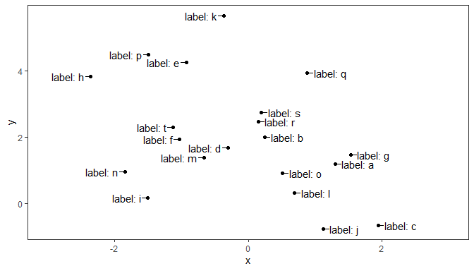

```r
ggplot(df, aes(x, y, label = l)) +
  geom_point() +
  geom_text_s(position = position_nudge_center(x = 0.1,
                                               center_x = median,
                                               direction = "split")) +
  expand_limits(x = c(-3, 3))
```

We set a different split point as the value computed by an anonymous function. Here we split on the first quartile along *x*.

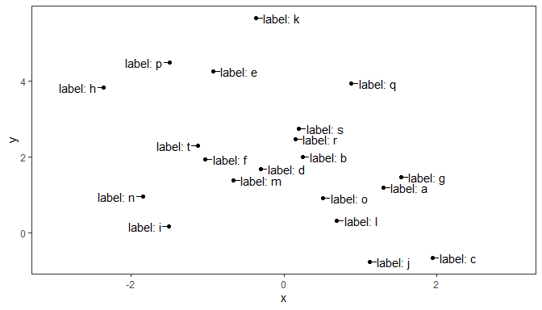

```r
ggplot(df, aes(x, y, label = l)) +
  geom_point() +
  geom_text_s(position =
                    position_nudge_center(x = 0.1,
                                          center_x = function(x) {
                                            quantile(x,
                                                     probs = 1/4,
                                                     names = FALSE)
                                          },
                                          direction = "split")) +
  expand_limits(x = c(-3, 3))
```

### position_nudge_line()

Function `position_nudge_line()` nudges away from a line, which can be a user supplied straight line as well as a smooth spline or a polynomial fitted to the observations themselves. The nudging is away and perpendicular to the local slope of the straight or curved line. It relies on the same assumptions as linear regression, assuming that *x* values are not subject to error. This in most cases prevents labels from overlaping a curve fitted to the data, even if not exactly based on the same model fit. When observations are sparse, this may be enough to obtain a nice arrangement of data labels.

```r
set.seed(16532)
df <- data.frame(
  x = -10:10,
  y = (-10:10)^2,
  yy = (-10:10)^2 + rnorm(21, 0, 4),
  yyy = (-10:10) + rnorm(21, 0, 4),
  l = letters[1:21]
)
```

The first, simple example shows that `position_nudge_line()` has shifted the direction of the nudging based on the alignment of the observations along a line. One could, of course, have in this case passed suitable values as arguments to *x* and *y* using `position_nudge()` from package ‘ggplot2’. However, `position_nudge_line()` will work without change irrespective of the slope or intercept along which the observations fall.

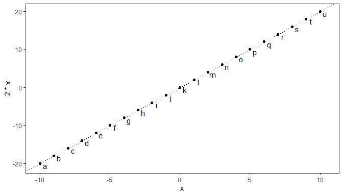

```r
ggplot(df, aes(x, 2 * x, label = l)) +
  geom_point() +
  geom_abline(intercept = 0, slope = 2, linetype = "dotted") +
  geom_text(position = position_nudge_line(x = -0.5, y = -0.8))
```

With observations with high variation in *y*, a linear model fit may need to be used. In this case fitted twice, once in `stat_smooth()` and once in `position_nudge_line()`.

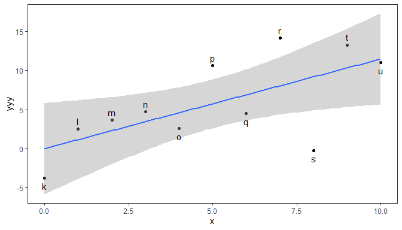

```r
ggplot(subset(df, x >= 0), aes(x, yyy)) +
  geom_point() +
  stat_smooth(method = "lm", formula = y ~ x) +
  geom_text(aes(label = l),
            vjust = "center", hjust = "center",
            position = position_nudge_line(x = 0, y = 1.2,
                                           method = "lm",
                                           direction = "split"))
```

With lower variation in *y*, we can pass to `line_nudge` a multiplier to keep labels outside of the confidence band.

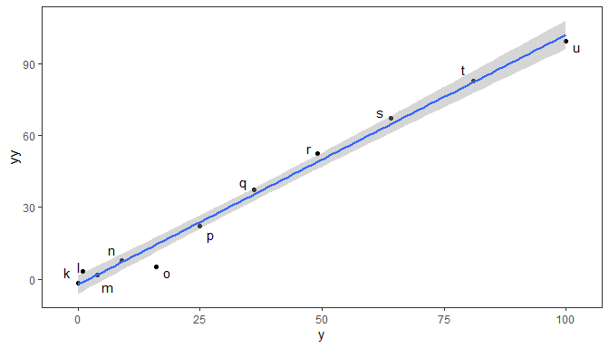

```r
ggplot(subset(df, x >= 0), aes(y, yy)) +
  geom_point() +
  stat_smooth(method = "lm", formula = y ~ x) +
  geom_text(aes(label = l),
            position = position_nudge_line(method = "lm",
                                           x = 3, y = 3,
                                           line_nudge = 2.5,
                                           direction = "split"))
```

If we want the nudging based on an arbitrary straight line not computed from `data`, we can pass the intercept and slope in a numeric vector of length two as an argument to parameter `abline`.

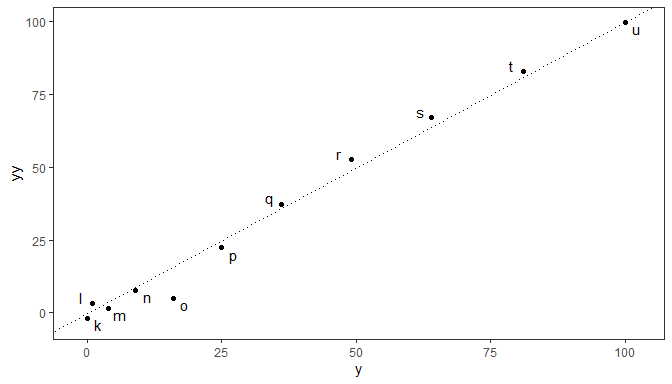

```r
ggplot(subset(df, x >= 0), aes(y, yy)) +
  geom_point() +
  geom_abline(intercept = 0, slope = 1, linetype = "dotted") +
  geom_text(aes(label = l),
            position = position_nudge_line(abline = c(0, 1),
                                           x = 3, y = 3,
                                           direction = "split"))
```

With observations that follow exactly a simple curve the defaults work well to automate the nudging of individual data labels away from the implicit curve. Positive values as arguments to `x` and `y` correspond to above and inside the curve. One could, of course, pass also in this case suitable values as arguments to *x* and *y* using `position_nudge()` from package ‘ggplot2’, but these arguments would need to be vectors with different *nudge* values for each observation.

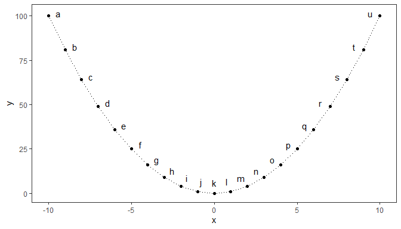

```r
ggplot(df, aes(x, y, label = l)) +
  geom_point() +
  geom_line(linetype = "dotted") +
  geom_text(position = position_nudge_line(x = 0.6, y = 6))
```

Negative values passed as arguments to `x` and `y` correspond to labels below and outside the curve.

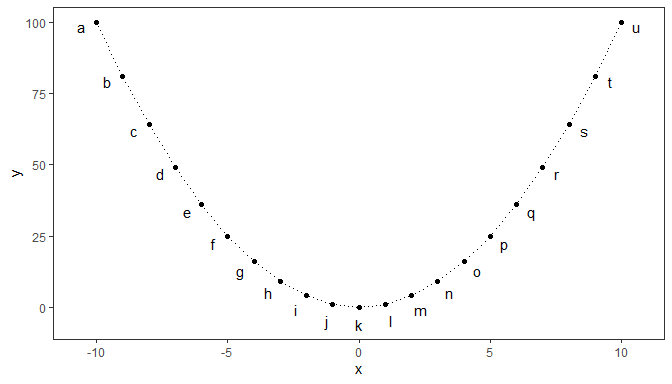

```r
ggplot(df, aes(x, y, label = l)) +
  geom_point() +
  geom_line(linetype = "dotted") +
  geom_text(position = position_nudge_line(x = -0.6, y = -6))
```

When the observations include random variation along *y*, it is important that the smoother used for the line added to a plot and that passed to `position_nudge_line()` are similar. By default `stat_smooth()` uses `"loess"` and `position_nudge_line()` with method `"spline"`, `smooth.sline()`, which are a good enough match.

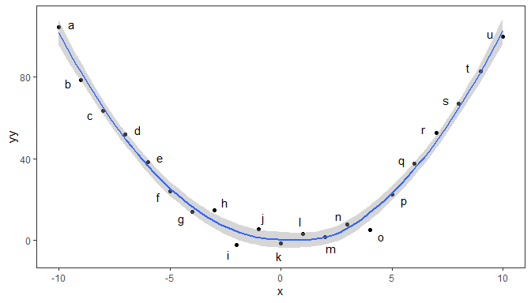

```r
ggplot(df, aes(x, yy)) +
  geom_point() +
  stat_smooth(method = "loess", formula = y ~ x) +
  geom_text(aes(label = l),
            position = position_nudge_line(x = 0.6,
                                           y = 6,
                                           direction = "split"))
```

We can use other geometries.

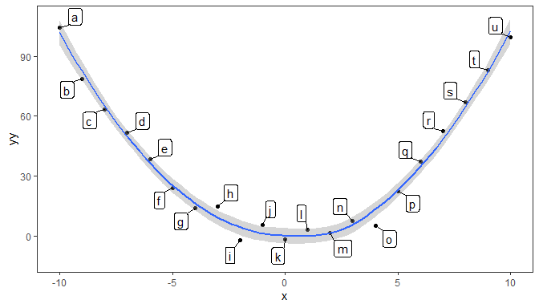

```r
ggplot(df, aes(x, yy)) +
  geom_point() +
  stat_smooth(method = "loess", formula = y ~ x) +
  geom_label_s(aes(label = l),
                   position = position_nudge_line(x = 0.4,
                                                  y = 4,
                                                  direction = "split")) +
  expand_limits(y = -12)
```

When fitting a polynomial, `"lm"` should be the argument passed to `method` and a model formula preferably based on `poly()`, setting `raw = TRUE`, as argument to `formula`. *Currently no other methods are implemented in* `position_nudge_line()`.

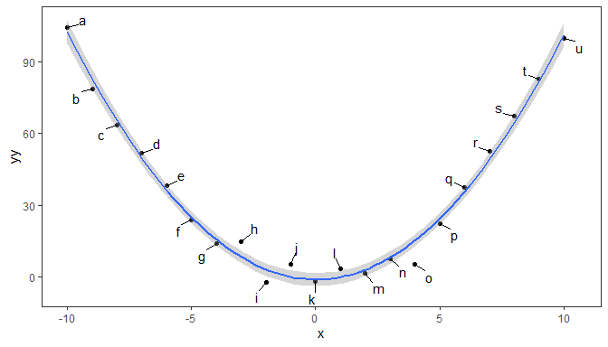

```r
ggplot(df, aes(x, yy)) +
  geom_point() +
  stat_smooth(method = "lm", formula = y ~ poly(x, 2, raw = TRUE)) +
  geom_text_s(aes(label = l),
              position = position_nudge_line(method = "lm",
                                             x = 0.5,
                                             y = 5,
                                             formula = y ~ poly(x, 2, raw = TRUE),
                                             direction = "split"))
```

## Combined position functions

As mentioned above, while *jitter* and *dodge* are normally use to displace the observations being plotted to avoid overlaps and *stack* used to construct columns or areas that represent sums and contributions to a sum from different groups of observations, *nudge* is almost always used to displace the position of data labels relative to observations they are attached to, to avoid overlaps. Because *nudge* plays in most cases a different role than *jitter*, *dodge*, and *stack*, rather frequently it is useful to combine *nudge* with the other position displacements. Additional examples for this use case are given in the `vignette("Combining repulsion and nudging")`.

Nudging text or labels in a dodged or stacked bar or column plot has not been easy in ‘ggplot2’. This is a rather frequent situation. However, within ‘ggplot2’ and the Grammar of Graphics this imposed some limitations on the design of plots and the need to use workarounds to modify the data before plotting.

Package ‘ggpp’ implements *position* functions that implement the functionality of more than one of the position functions available in ‘ggplot2’. The examples below demonstrate their use.

Combined position functions defined in package ‘ggpp’

| Position | Main use | Displacement | Most used with |
| --- | --- | --- | --- |
| `position_stacknudge()` | stack + nudge | combined, see above | data labels in column plots |
| `position_fillnudge()` | fill + nudge | combined, see above | data labels in column plots |
| `position_jitternudge()` | jitter + nudge | combined, see above | data labels in dot plots |
| `position_dodgenudge()` | dodge + nudge | combined, see above | data labels in column plots |
| `position_dodge2nudge()` | dodge2 + nudge | combined, see above | data labels in box plots |

**In all cases when labelling points or columns, to achieve the correct alignment, the arguments passed to the equivalent position functions used for observations and text must be the same, except for `x` and `y` which determine amount of nudging to be added to the other dispalcements.**

All the position functions described in this section are compatible with most geometries from `ggpplot2` and extensions. However, only those from packages ‘ggpp’ and ‘ggrepel’ (> 0.9.1) plot segments and arrows linking original and displaced positions using the saved original positions as “kept”, or saved, by these position functions.

```r
 df <- data.frame(x1 = c(1, 2, 1, 3, -1),
                  x2 = c("a", "a", "b", "b", "b"),
                  grp = c("A", "B", "C", "D", "E"))
```

### position_dodgenudge()

When labelling dodged columns, we can in addition apply nudging. Here we add a label just outside the tip of each horizontal bar. With `direction = "split"` we ensure that the text is correctly located in the *negative* columns.

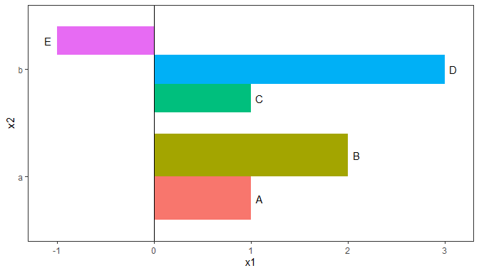

```r
ggplot(data = df, aes(x1, x2, group = grp)) +
   geom_col(aes(fill = grp), width = 0.8,
            position = position_dodge()) +
   geom_vline(xintercept = 0) +
   geom_text(
     aes(label = grp),
     position = position_dodgenudge(x = 0.09, direction = "split", width = 0.8)) +
   theme(legend.position = "none")
```

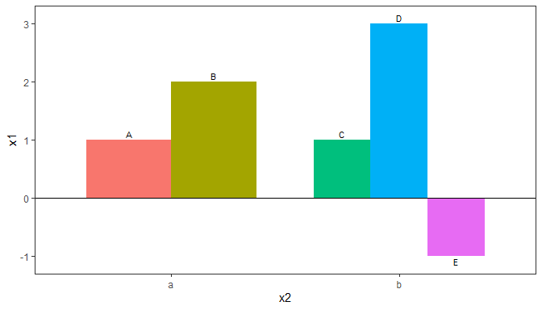

```r
 ggplot(data = df, aes(x2, x1, group = grp)) +
   geom_col(aes(fill = grp), width = 0.75,
            position = position_dodge(width = 0.75)) +
   geom_hline(yintercept = 0) +
   geom_text(aes(label = grp),
             position = position_dodgenudge(y = 0.1,
                                            direction = "split",
                                            width = 0.75),
             size = 3) +
   theme(legend.position = "none")
```

### position_stacknudge()

With horizontally stacked bar we add labels above each bar, at their horizontal center with `vjust = 0.5`. (As with text, the justification is relative, with vertical always meaning along the direction representing continuous data values or counts.)

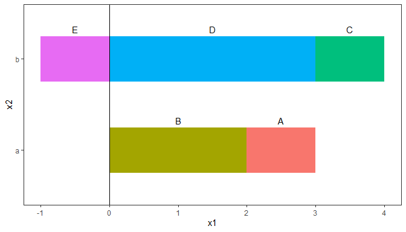

```r
 ggplot(data = df, aes(x1, x2, group = grp)) +
   geom_col(aes(fill = grp), width = 0.5) +
   geom_vline(xintercept = 0) +
   geom_text(
     aes(label = grp),
     position = position_stacknudge(vjust = 0.5, y = 0.33)) +
   theme(legend.position = "none")
```

### position_fillnudge()

Here we nudge the labels down from the top of each stacked bar with `vjust = 1`.

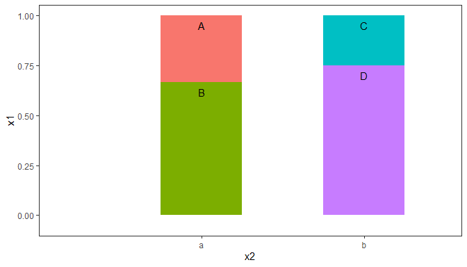

```r
 ggplot(data = subset(df, x1 >= 0), aes(x2, x1, group = grp)) +
   geom_col(aes(fill = grp), width=0.5, position = position_fill()) +
   geom_vline(xintercept = 0) +
   geom_text(
     aes(label = grp),
     position = position_fillnudge(vjust = 1, y = -0.05)) +
   theme(legend.position = "none")
```

### position_stack_minmax()

Functions `position_stack()` and `position_stack_nudge()` from package ‘ggplot2’ displace the position of a variable mapped to only one of `y`, `ymax` or `ymin`. So they cannot be used with geometries `geom_linerange()`, `geom_pointrange()` or `geom_errorbar()`. Position function `position_stack_minmax()` can be used with these geometries as it displaces `y`, `ymin` and `ymax` together by the same distance. Like `position_stack_nudge()` it also supports nudging. Thus, this new position function makes it possible to add error bars to each member of a stacked colum plot. As nudging is also supported, it is possible, as shown below, to also include an error bar for the total quantity represented by the stacked bars.

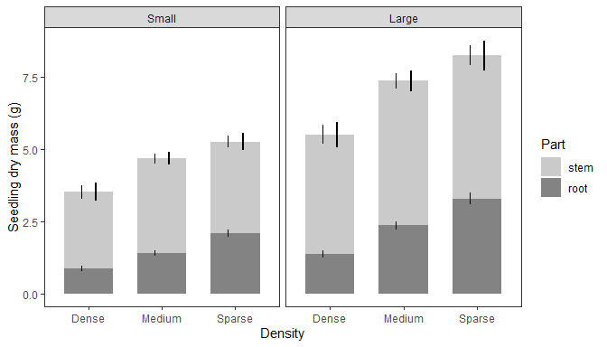

```r
ggplot(birch_dw.df,
       aes(y = dry.weight * 1e-3, x = Density, fill = Part)) +
  stat_summary(geom = "col", fun = mean,
               position = "stack", alpha = 0.7, width = 0.67) +
  # error bars for each stack bar
  stat_summary(geom = "linerange", fun.data = mean_cl_normal,
               position = position_stack_minmax(x = -0.1)) +
  # error bar for the total
  stat_summary(data = birch.df, aes(y = (dwstem + dwroot) * 1e-3, fill = NULL),
               geom = "linerange", linewidth = 0.75,
               position = position_nudge(x = 0.1), fun.data = mean_cl_normal) +
  labs(y = "Seedling dry mass (g)") +
  scale_fill_grey(start = 0.7, end = 0.3) +
  facet_wrap(facets = vars(Container))
```

### position_jitternudge()

When combining jitter and nudge, we can nudge away from the jittered positions or from the original positions. In this example, we nudge away from the jittered positions with `nudge.from = "jittered"` and the direction of the nudge is on either side of the original position with `direction = "split"`, with nudging depending on the direction the jitter has moved the point.

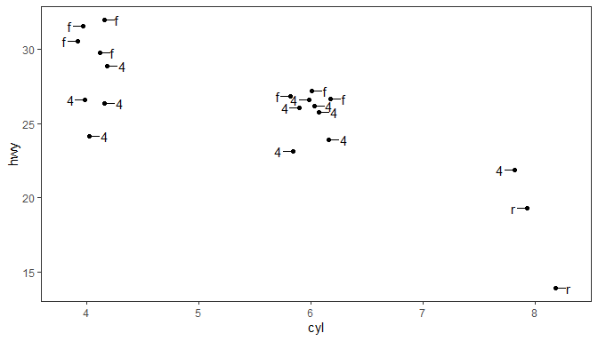

```r
 jitter <- position_jitter(width = 0.2, height = 2, seed = 123)

 jitter_nudge <- position_jitternudge(width = 0.2, height = 2,
                                      seed = 123, x = 0.1,
                                      direction = "split",
                                      nudge.from = "jittered")
 ggplot(mpg[1:20, ],
        aes(cyl, hwy, label = drv)) +
   geom_point(position = jitter) +
   geom_text_s(position = jitter_nudge)
```

In this second example, the nudging is away from the original *x*-position while using the jittered *y*-position, which gives vertically aligned labels.

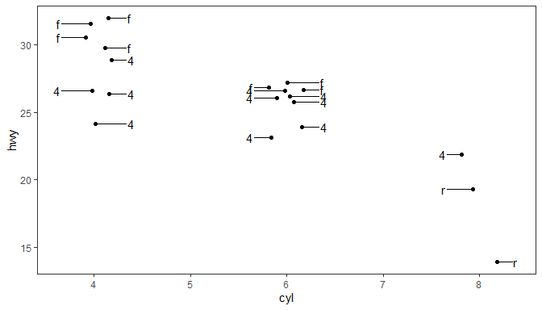

```r
jitter <- position_jitter(width = 0.2, height = 2, seed = 123)

jitter_nudge <- position_jitternudge(width = 0.2, height = 2,
                                      seed = 123, x = 0.35,
                                      direction = "split",
                                      nudge.from = "original.x")
 ggplot(mpg[1:20, ],
        aes(cyl, hwy, label = drv)) +
   geom_point(position = jitter) +
   geom_text_s(position = jitter_nudge)
```

### position_jitter_keep()

With no nudging but keeping the original positions we show how points have moved with jitter.

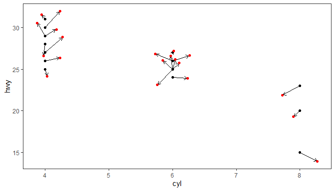

```r
 ggplot(mpg[1:20, ],
        aes(cyl, hwy, label = drv)) +
   geom_point() +
   geom_point_s(position =
                position_jitter_keep(width = 0.3, height = 2, seed = 123),
                color = "red")
```

## Appendix A: More on density filtering

This appendix includes additional examples of the use of the local-density-based filtering. These additional examples show the behaviour of these statistics with with pseudo-random artificial data based on different theoretical probability density functions. Here we use the `_filter` variants of these statistics. The companion `_labels` variants are meant to be used together with the repulsive geometries from package ‘ggrepel’.

To start, we define a function to simplify the generation of random data sets based on different probability distributions.

```r
make_data_tbl <- function(nrow = 100, rfun = rnorm, ...) {
  if (nrow %% 2) {
    nrow <- nrow + 1
  }

  set.seed(1001)

  tibble::tibble(
    x = rfun(nrow, ...),
    y = rfun(nrow, ...),
    group = rep(c("A", "B"), c(nrow / 2, nrow / 2))
  )
}
```

In all the examples in this section of the vignette we use colours to demonstrate which data points are selected, but any other suitable aesthetic and discrete scale can be used instead. By overriding the default `keep.sparse = TRUE` with `keep.sparse = FALSE` we keep 1/3 of the observations in the denser region of the plot. Although here we first plot all data points and later overplot the selected ones this is not necessary.

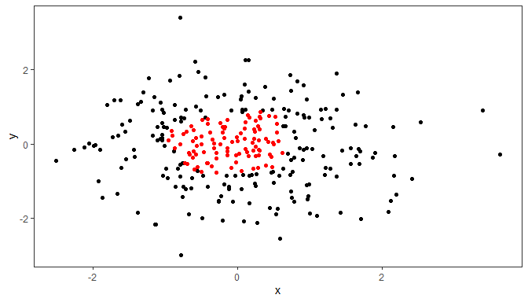

```r
ggplot(data = make_data_tbl(300), aes(x, y)) +
  geom_point() +
  stat_dens2d_filter(colour = "red",
                     keep.sparse = FALSE,
                     keep.fraction = 1/3)
```

Here we highlight the observations split into three groups, each containing 1/3 of the observations in `data`. Each group, corresponding to a different local density of observations.

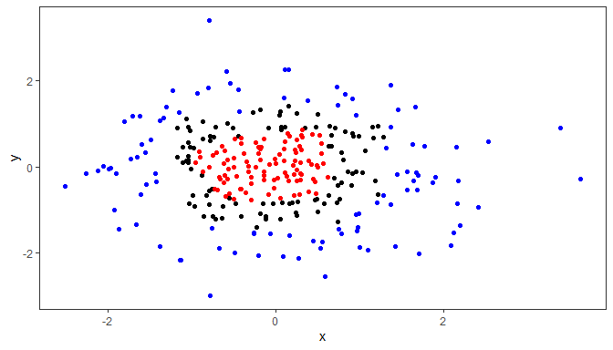

```r
ggplot(data = make_data_tbl(300), aes(x, y)) +
  geom_point() +
  stat_dens2d_filter(colour = "red",
                     keep.sparse = FALSE,
                     keep.fraction = 1/3)+
  stat_dens2d_filter(colour = "blue",
                     keep.fraction = 1/3)
```

The algorithm seems to work well also with other distributions, in this example we use the uniform distribution.

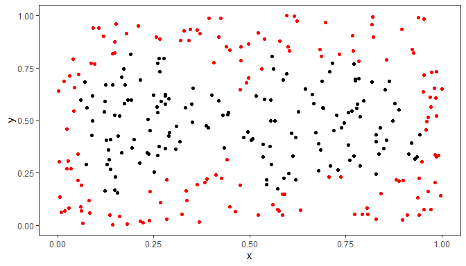

```r
ggplot(data = make_data_tbl(300, rfun = runif), aes(x, y)) +
  geom_point() +
  stat_dens2d_filter(colour = "red", keep.fraction = 1/2)
```

One example with the gamma distribution, which is asymmetric.

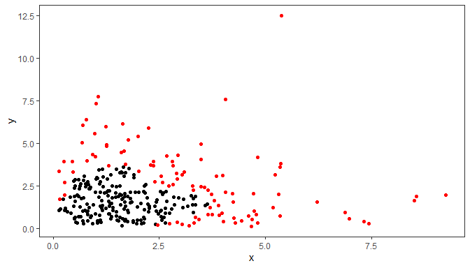

```r
ggplot(data = make_data_tbl(300, rfun = rgamma, shape = 2),
       aes(x, y)) +
  geom_point() +
  stat_dens2d_filter(colour = "red", keep.fraction = 1/3)
```

## Appendix B: try_tibble()

### Time series

Several different formats for storing time series data are used in R. Here we use in the examples objects of class `ts` but several other classes are supported as `try.xts()` from package ‘xts’ is used internally. Package ‘ggplot2’ supports plotting with variables containing date-times represented as objects of classes `POSIXct` or `Date`. Functions `try_data_frame()` and `try_tibble()` are used in ‘ggpp’ internally in the definition of `ggplot()` method for time series data. Non-the-less, `try_data_frame()` and `try_tibble()` are exported. The two functions differ only in the class of the returned object. The time variable in the returned data frame or tibble by default belongs to class `Date` or to class `POSIXct` depending on the time step of the time series object. In the examples below we use `try_tibble()` but they work unchanged with `try_data_frame()`.

In the first example we convert a quarterly time series into a tibble.

```r
print(austres)
```

```
##         Qtr1    Qtr2    Qtr3    Qtr4
## 1971         13067.3 13130.5 13198.4
## 1972 13254.2 13303.7 13353.9 13409.3
## 1973 13459.2 13504.5 13552.6 13614.3
## 1974 13669.5 13722.6 13772.1 13832.0
## 1975 13862.6 13893.0 13926.8 13968.9
## 1976 14004.7 14033.1 14066.0 14110.1
## 1977 14155.6 14192.2 14231.7 14281.5
## 1978 14330.3 14359.3 14396.6 14430.8
## 1979 14478.4 14515.7 14554.9 14602.5
## 1980 14646.4 14695.4 14746.6 14807.4
## 1981 14874.4 14923.3 14988.7 15054.1
## 1982 15121.7 15184.2 15239.3 15288.9
## 1983 15346.2 15393.5 15439.0 15483.5
## 1984 15531.5 15579.4 15628.5 15677.3
## 1985 15736.7 15788.3 15839.7 15900.6
## 1986 15961.5 16018.3 16076.9 16139.0
## 1987 16203.0 16263.3 16327.9 16398.9
## 1988 16478.3 16538.2 16621.6 16697.0
## 1989 16777.2 16833.1 16891.6 16956.8
## 1990 17026.3 17085.4 17106.9 17169.4
## 1991 17239.4 17292.0 17354.2 17414.2
## 1992 17447.3 17482.6 17526.0 17568.7
## 1993 17627.1 17661.5
```

```r
class(austres)
```

```
## [1] "ts"
```

```r
austres.df <- try_tibble(austres)
class(austres.df)
```

```
## [1] "tbl_df"     "tbl"        "data.frame"
```

```r
head(austres.df, 4)
```

```
## # A tibble: 4 × 2
##   time            x
##   <date>      <dbl>
## 1 1971-04-01 13067.
## 2 1971-07-01 13130.
## 3 1971-10-01 13198.
## 4 1972-01-01 13254.
```

The next chunk demonstrates that when passing `as.numeric = TRUE` to override the default, numeric times are expressed as years with decimal fractions in the returned data frame.

```r
austres.df <- try_tibble(austres, as.numeric = TRUE)
head(austres.df, 4)
```

```
## # A tibble: 4 × 2
##    time      x
##   <dbl>  <dbl>
## 1 1971. 13067.
## 2 1971. 13130.
## 3 1972. 13198.
## 4 1972  13254.
```

This additional example is for a series of yearly values.

```r
class(lynx)
```

```
## [1] "ts"
```

```r
lynx.df <- try_tibble(lynx)
class(lynx.df)
```

```
## [1] "tbl_df"     "tbl"        "data.frame"
```

```r
head(lynx.df, 3)
```

```
## # A tibble: 3 × 2
##   time           x
##   <date>     <dbl>
## 1 1821-01-01   269
## 2 1822-01-01   321
## 3 1823-01-01   585
```

In some cases there can be small rounding errors or the time steps can be shorter that the default `time.resolution = "month"`. We should in those cases pass an argument to `time.resolution` to override the default rounding. Rounding is done with `lubridate::round_date()` and the argument from `time.resolution` passed to its parameter `unit`, except if it is `NULL` or `NA`, in which case no rounding is applied.

```r
lynx.df <- try_tibble(lynx, time.resolution = NULL)
head(lynx.df, 3)
```

```
## # A tibble: 3 × 2
##   time           x
##   <date>     <dbl>
## 1 1821-01-01   269
## 2 1822-01-01   321
## 3 1823-01-01   585
```

In addition we can convert the POSIXct values into numeric values in calendar years plus a decimal fraction.

```r
lynx_n.df <- try_tibble(lynx, time.resolution = "year", as.numeric = TRUE)
lapply(lynx_n.df, "class")
```

```
## $time
## [1] "numeric"
##
## $x
## [1] "numeric"
```

```r
head(lynx_n.df, 3)
```

```
## # A tibble: 3 × 2
##    time     x
##   <dbl> <dbl>
## 1  1821   269
## 2  1822   321
## 3  1823   585
```

### Other classes

Functions `try_data_frame()` and `try_tibble()` attempt to handle gracefully objects that are not time series.

```r
try_tibble(1:5)
```

```
## # A tibble: 5 × 1
##       x
##   <int>
## 1     1
## 2     2
## 3     3
## 4     4
## 5     5
```

```r
try_tibble(letters[1:5])
```

```
## # A tibble: 5 × 1
##   x
##   <chr>
## 1 a
## 2 b
## 3 c
## 4 d
## 5 e
```

```r
try_tibble(factor(letters[1:5]))
```

```
## # A tibble: 5 × 1
##   x
##   <fct>
## 1 a
## 2 b
## 3 c
## 4 d
## 5 e
```

```r
try_tibble(list(x = rep(1,5), y = 1:5))
```

```
## # A tibble: 5 × 2
##       x     y
##   <dbl> <int>
## 1     1     1
## 2     1     2
## 3     1     3
## 4     1     4
## 5     1     5
```

```r
try_tibble(data.frame(x = rep(1,5), y = 1:5))
```

```
## # A tibble: 5 × 2
##       x     y
##   <dbl> <int>
## 1     1     1
## 2     1     2
## 3     1     3
## 4     1     4
## 5     1     5
```

```r
try_tibble(matrix(1:10, ncol = 2))
```

```
## # A tibble: 5 × 2
##      V1    V2
##   <int> <int>
## 1     1     6
## 2     2     7
## 3     3     8
## 4     4     9
## 5     5    10
```